# Analysis of ‘Math Benefits the Community’ Experiment on Khan Academy

Dave Paunesku & Ben Haley

September 26, 2014

# Abstract

Students were shown messages that emphasize the benefit of math to the community. We hoped this would increase the rate students master new math skills. Across the whole population there was a small, negative effect. However, the messages affected different groups of users in different ways. There was a small, negative effect on supervised (“coached”) students. In contrast, there was a substantial, positive effect for experienced, uncoached users. This group accounts for approximately 5% of users and 16% of correctly answered problems. Members of this group attained 13% more level 3 masteries in the treatment condition than control. This effect did not appear to dissipate over the 30 days over which data were examined. We hope to revise this intervention to target the users who are most likely to benefit from it.

# About this Document

# Study Summary

## Background

This is one of two social psychology experiments run at Khan Academy as part of the [Mindset Challenge](http://www.perts.net/challenge). The intervention materials were designed by Belanger, Steinberg, and Diekman at the invitation of [PERTS](http://www.perts.net) and [Khan Academy](http://www.khanacademy.org). The project was funded by the [Raikes Foundation](http://raikesfoundation.org/). Experiments were implemented by Ben Haley and Daniel Greene.

## Hypothesis

Students who see messages emphasizing the benefit of math to the community will be more engaged and outperform those who see no messages.

## Treatments

Students are shown messages above exercises that emphasize the benefit of math to people and communities (as opposed to scientists isolated on secret island fortresses).

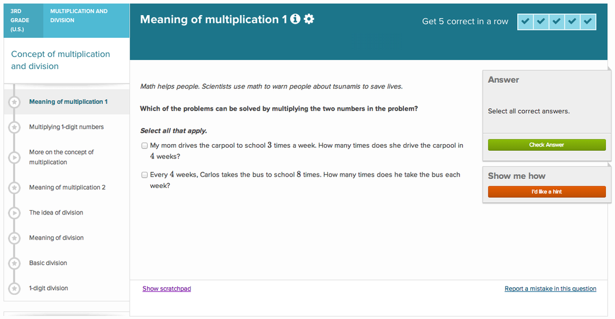

## Whole Sample Results

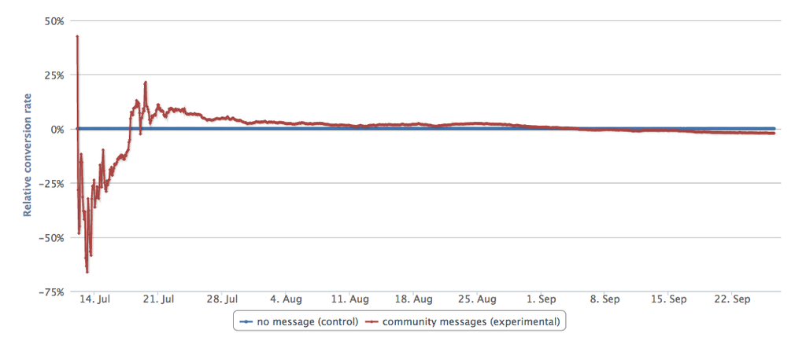

Similar results were seen for problem correct and return visits. See the [mad scientist dashboard](https://www.khanacademy.org/bigbingo/experiment/psych_header_math_benefits_the_community) for more details.

## Subgroup Results

There was also a larger, positive effect among experienced, uncoached users – those who had at least one mastery promotion before receiving the intervention and whose progress on Khan Academy is unsupervised by someone else (like a parent or teacher). Experienced, uncoached users earned 13% more level 3 masteries over the next 30 days if assigned to the treatment group. This effect appeared to maintain over time.

## Future Directions

In light of these findings, we intend to replicate this experiment focusing only on the uncoached users who appear to benefit from these messages. We will also continue to monitor the longer term effects on participants in this initial experiment.

# Detailed Methods

## Dependencies

This analysis requires several libraries and helper functions.

```r
library(dplyr)
library(ggplot2)
library(texreg)
library(reshape2)

# Load HELPER FUNCTIONS
source("~/perts_analyses/challenge belanger analyses/helper_functions.R")
```

## Variable Definitions

See Belanger Data Prep for the code used to calculate variables.

### Baseline Variables

- `skill_change_pre` the number of skill points earned in the 30 days prior to the intervention start
- `condition` control or treatment
- `coached` whether the user has a coach assigned (i.e, whether they are supervised on Khan Academy by a teacher, parent, or someone else)
- `newbie` whether the person earned any masteries in the 30 days prior to treatment

### Outcome Variables

- `skill_change` the number of skill points earned
- `improved_log` log of the number of skill points earned
- `improved_bin` whether or not the user exhibited a growth in skills
- `mastery3` number of level 3 masteries earned
- `mastery3_log` log of number of level 3 masteries earned
- `mastery3_bin` whether or not the user earned at least 1 level 3 mastery
- `mastery1` like `mastery3` but for level 1
- `mastery1_log` like `mastery3_log` but for level 1
- `mastery1_bin` like `mastery3_bin` but for level 1
- `total_active_hours` number of unique hours user was on site

### Datasets

There are two datasets, each of which contain data from the day students were exposed to the intervention (day 0), the 30 days prior to exposure, and the 30 days following exposure.

`w` has all pre and post outcomes aggregated to the user level. Pre-exposure days are marked “pre”.

`d` has outcomes aggregated to the level of each day for each user.

```r
# Load Pre-Processed Data
setwd("~/Dropbox/studies/ka belanger")
d <- read.csv("daily.csv",stringsAsFactors=FALSE)
w <- read.csv("wide.csv",stringsAsFactors=FALSE)
```

## Condition Effects on Mastery

### How Are Users’ Skills Changing as a Result of Intervention?

Visualize changes in masteries by each subgroup and condition.

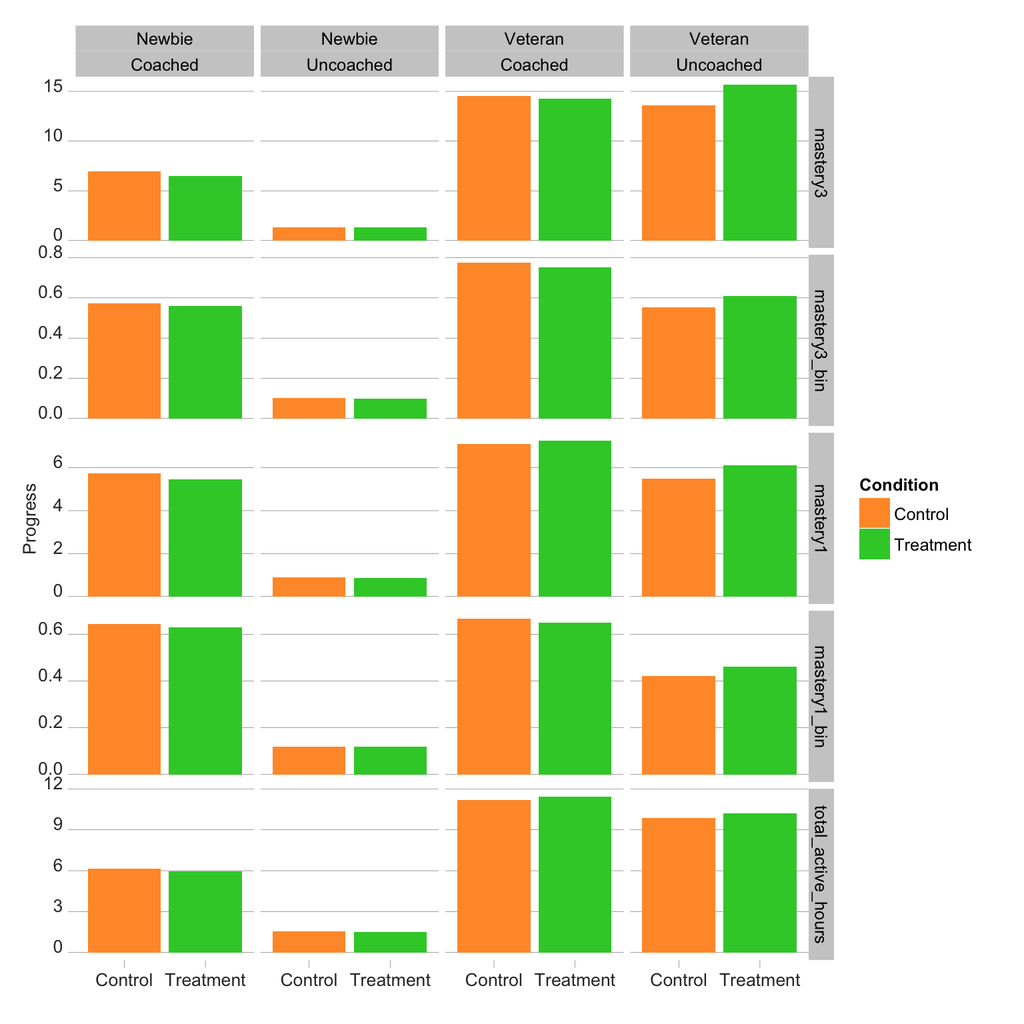

```r
gdf <- group_by(w, newbie, coached, condition ) %.%
  summarise( mastery3=mean(mastery3) ,
             mastery3_bin=mean(mastery3_bin),
             mastery1=mean(mastery1) ,
             mastery1_bin=mean(mastery1_bin),
             total_active_hours=mean(total_active_hours)
             )

# melt the data for graphing
m <- melt( gdf , id.vars=c("condition","coached","newbie") )

# graph of absolute effects on various outcomes
ggplot( m, aes( condition, value, fill=condition ) ) +
  geom_bar( stat="identity", position="dodge" ) +
  facet_grid( variable ~ newbie + coached, scales="free"  ) +
  xlab("") + ylab("Progress") +
  fill_conditions_scale + ht
```

```r
# table of absolute effects on various outcomes
c("condition","coached","newbie",
  "mastery3","total_active_hours") %>%
  gdf[,.] %>%
  pretty_table()
```

|  | condition | coached | newbie | mastery3 | total_active_hours |
| --- | --- | --- | --- | --- | --- |
| 1 | Control | Coached | Newbie | 6.93 | 6.14 |
| 2 | Treatment | Coached | Newbie | 6.50 | 5.96 |
| 3 | Control | Uncoached | Newbie | 1.35 | 1.55 |
| 4 | Treatment | Uncoached | Newbie | 1.31 | 1.51 |
| 5 | Control | Coached | Veteran | 14.51 | 11.21 |
| 6 | Treatment | Coached | Veteran | 14.23 | 11.44 |
| 7 | Control | Uncoached | Veteran | 13.57 | 9.85 |
| 8 | Treatment | Uncoached | Veteran | 15.69 | 10.22 |

### Effects on Numerical Outcomes

OLS models show strong interactions between user type and treatment.

```r
model <- lm( mastery3_log ~ condition * coached * newbie
             + skill_change_pre, data=w )
pretty_table(model)
```

|  | Estimate | Std. Error | t value | Pr(>\|t\|) |
| --- | --- | --- | --- | --- |
| (Intercept) | 1.1950 | 0.0051 | 235.38 | 0.0000 |
| conditionTreatment | -0.0481 | 0.0072 | -6.70 | 0.0000 |
| coachedUncoached | -0.9941 | 0.0059 | -168.71 | 0.0000 |
| newbieVeteran | 0.4503 | 0.0187 | 24.10 | 0.0000 |
| skill_change_pre | 0.0050 | 0.0001 | 62.73 | 0.0000 |
| conditionTreatment:coachedUncoached | 0.0437 | 0.0083 | 5.24 | 0.0000 |
| conditionTreatment:newbieVeteran | -0.0172 | 0.0258 | -0.67 | 0.5045 |
| coachedUncoached:newbieVeteran | 0.4650 | 0.0257 | 18.10 | 0.0000 |
| conditionTreatment:coachedUncoached:newbieVeteran | 0.1366 | 0.0364 | 3.75 | 0.0002 |

```r
pretty_table(
    aggregate( mastery3_log ~ condition * coached * newbie ,
           data=w, mean))
```

|  | condition | coached | newbie | mastery3_log |
| --- | --- | --- | --- | --- |
| 1 | Control | Coached | Newbie | 1.19 |
| 2 | Treatment | Coached | Newbie | 1.15 |
| 3 | Control | Uncoached | Newbie | 0.20 |
| 4 | Treatment | Uncoached | Newbie | 0.20 |
| 5 | Control | Coached | Veteran | 1.93 |
| 6 | Treatment | Coached | Veteran | 1.87 |
| 7 | Control | Uncoached | Veteran | 1.45 |
| 8 | Treatment | Uncoached | Veteran | 1.58 |

```r
model <- lm( mastery3_log ~ condition * newbie +
             + skill_change_pre,
             data=w[w$coached %in% "Coached",] )
pretty_table(model)
```

|  | Estimate | Std. Error | t value | Pr(>\|t\|) |
| --- | --- | --- | --- | --- |
| (Intercept) | 1.1950 | 0.0071 | 167.56 | 0.0000 |
| conditionTreatment | -0.0482 | 0.0101 | -4.77 | 0.0000 |
| newbieVeteran | 0.3982 | 0.0280 | 14.20 | 0.0000 |
| skill_change_pre | 0.0059 | 0.0002 | 28.93 | 0.0000 |
| conditionTreatment:newbieVeteran | -0.0170 | 0.0362 | -0.47 | 0.6382 |

```r
model <- lm( mastery3_log ~ condition + newbie +
             + skill_change_pre,
             data=w[w$coached %in% "Coached",] )
pretty_table(model)
```

|  | Estimate | Std. Error | t value | Pr(>\|t\|) |
| --- | --- | --- | --- | --- |
| (Intercept) | 1.1957 | 0.0070 | 171.01 | 0.0000 |
| conditionTreatment | -0.0495 | 0.0097 | -5.10 | 0.0000 |
| newbieVeteran | 0.3897 | 0.0216 | 18.07 | 0.0000 |
| skill_change_pre | 0.0059 | 0.0002 | 28.93 | 0.0000 |

```r
pretty_table(
    aggregate( mastery3 ~ condition   ,
               data=w[w$coached %in% "Coached",], mean))
```

|  | condition | mastery3 |
| --- | --- | --- |
| 1 | Control | 7.52 |
| 2 | Treatment | 7.09 |

Among uncoached users, experience interacted with treatement to predict learning. Whereas condition did not affect skill acquisition among new, uncoached users, veteran uncoached users (those who attained at least one mastery in the 30 days pre-intervention) mastered approximately 13% more skills in the treatment condition over the 30 post-study days.

```r
model <- lm( mastery3_log ~ condition * newbie +
             + skill_change_pre,
             data=w[ w$coached %in% "Uncoached",] )
pretty_table(model)
```

|  | Estimate | Std. Error | t value | Pr(>\|t\|) |
| --- | --- | --- | --- | --- |
| (Intercept) | 0.2009 | 0.0024 | 83.75 | 0.0000 |
| conditionTreatment | -0.0045 | 0.0034 | -1.32 | 0.1868 |
| newbieVeteran | 0.9415 | 0.0155 | 60.83 | 0.0000 |
| skill_change_pre | 0.0046 | 0.0001 | 60.31 | 0.0000 |
| conditionTreatment:newbieVeteran | 0.1208 | 0.0207 | 5.85 | 0.0000 |

```r
model <- lm( mastery3_log ~ condition  +
             + skill_change_pre,
             data=w[  w$newbie %in% "Newbie" &
                      w$coached %in% "Uncoached",] )
pretty_table(model)
```

|  | Estimate | Std. Error | t value | Pr(>\|t\|) |
| --- | --- | --- | --- | --- |
| (Intercept) | 0.2008 | 0.0023 | 87.50 | 0.0000 |
| conditionTreatment | -0.0045 | 0.0032 | -1.38 | 0.1661 |
| skill_change_pre | -0.0952 | 0.0131 | -7.26 | 0.0000 |

```r
model <- lm( mastery3_log ~ condition  +
             + skill_change_pre,
             data=w[  w$newbie %in% "Veteran" &
                      w$coached %in% "Uncoached",] )
pretty_table(model)
```

|  | Estimate | Std. Error | t value | Pr(>\|t\|) |
| --- | --- | --- | --- | --- |
| (Intercept) | 1.1422 | 0.0307 | 37.18 | 0.0000 |
| conditionTreatment | 0.1163 | 0.0409 | 2.84 | 0.0045 |
| skill_change_pre | 0.0046 | 0.0002 | 30.04 | 0.0000 |

```r
pretty_table(
    aggregate( mastery3_log ~ condition + newbie ,
               data=w[w$coached %in% "Uncoached",], mean))
```

|  | condition | newbie | mastery3_log |
| --- | --- | --- | --- |
| 1 | Control | Newbie | 0.20 |
| 2 | Treatment | Newbie | 0.20 |
| 3 | Control | Veteran | 1.45 |
| 4 | Treatment | Veteran | 1.58 |

Among uncoached veterans, the positive effects were driven by increases in level 3 masteries. There was a smaller effect on level 1 masteries and no effect on merely practicing more concepts.

```r
model <- lm( mastery3_log ~ condition + skill_change_pre,
            data=w[ w$coached %in% "Uncoached" &
                    w$newbie %in% "Veteran",] )
pretty_table(model)
```

|  | Estimate | Std. Error | t value | Pr(>\|t\|) |
| --- | --- | --- | --- | --- |
| (Intercept) | 1.1422 | 0.0307 | 37.18 | 0.0000 |
| conditionTreatment | 0.1163 | 0.0409 | 2.84 | 0.0045 |
| skill_change_pre | 0.0046 | 0.0002 | 30.04 | 0.0000 |

```r
model <- lm( mastery1_log ~ condition + skill_change_pre,
            data=w[ w$coached %in% "Uncoached" &
                    w$newbie %in% "Veteran",] )
pretty_table(model)
```

|  | Estimate | Std. Error | t value | Pr(>\|t\|) |
| --- | --- | --- | --- | --- |
| (Intercept) | 0.6352 | 0.0247 | 25.77 | 0.0000 |
| conditionTreatment | 0.0612 | 0.0329 | 1.86 | 0.0625 |
| skill_change_pre | 0.0034 | 0.0001 | 28.11 | 0.0000 |

```r
model <- lm( practiced_log ~ condition + skill_change_pre,
            data=w[ w$coached %in% "Uncoached" &
                    w$newbie %in% "Veteran",] )
pretty_table(model)
```

|  | Estimate | Std. Error | t value | Pr(>\|t\|) |
| --- | --- | --- | --- | --- |
| (Intercept) | 1.3220 | 0.0269 | 49.20 | 0.0000 |
| conditionTreatment | 0.0148 | 0.0358 | 0.41 | 0.6797 |
| skill_change_pre | 0.0030 | 0.0001 | 22.47 | 0.0000 |

### Effects on Binary Outcomes

```r
# the three-way interaction
model <- glm( mastery3_bin ~ condition * coached * newbie +
            skill_change_pre,
            data=w,
            family="binomial"
            )
pretty_table(model)
```

|  | Estimate | Std. Error | z value | Pr(>\|z\|) |
| --- | --- | --- | --- | --- |
| (Intercept) | 0.2963 | 0.0116 | 25.56 | 0.0000 |
| conditionTreatment | -0.0575 | 0.0164 | -3.51 | 0.0004 |
| coachedUncoached | -2.4803 | 0.0161 | -153.87 | 0.0000 |
| newbieVeteran | 0.3285 | 0.0531 | 6.19 | 0.0000 |
| skill_change_pre | 0.0156 | 0.0006 | 25.33 | 0.0000 |
| conditionTreatment:coachedUncoached | 0.0451 | 0.0228 | 1.98 | 0.0481 |
| conditionTreatment:newbieVeteran | -0.0541 | 0.0701 | -0.77 | 0.4404 |
| coachedUncoached:newbieVeteran | 1.4004 | 0.0679 | 20.63 | 0.0000 |
| conditionTreatment:coachedUncoached:newbieVeteran | 0.3002 | 0.0957 | 3.14 | 0.0017 |

```r
# negative effect on coached users
model <- glm( mastery3_bin ~ condition + newbie + skill_change_pre,
            data=w[ w$coached %in% "Coached",] ,
            family="binomial"
            )
pretty_table(model)
```

|  | Estimate | Std. Error | z value | Pr(>\|z\|) |
| --- | --- | --- | --- | --- |
| (Intercept) | 0.2978 | 0.0114 | 26.04 | 0.0000 |
| conditionTreatment | -0.0603 | 0.0159 | -3.79 | 0.0002 |
| newbieVeteran | 0.2144 | 0.0459 | 4.67 | 0.0000 |
| skill_change_pre | 0.0189 | 0.0011 | 16.68 | 0.0000 |

```r
gdf <- aggregate( mastery3_bin ~  condition  ,
            data=w[ w$coached %in% "Coached",] ,
            mean )
pretty_table(gdf)
```

|  | condition | mastery3_bin |
| --- | --- | --- |
| 1 | Control | 0.59 |
| 2 | Treatment | 0.57 |

```r
# positive effect among uncoached veterans
model <- glm( mastery3_bin ~ condition + skill_change_pre,
            data=w[ w$coached %in% "Uncoached" &
                    w$newbie %in% "Veteran",] ,
            family="binomial"
            )
pretty_table(model)
```

|  | Estimate | Std. Error | z value | Pr(>\|z\|) |
| --- | --- | --- | --- | --- |
| (Intercept) | -0.4094 | 0.0495 | -8.27 | 0.0000 |
| conditionTreatment | 0.2322 | 0.0626 | 3.71 | 0.0002 |
| skill_change_pre | 0.0141 | 0.0007 | 19.45 | 0.0000 |

```r
# means by group
gdf <- aggregate( mastery3_bin ~  condition * coached * newbie ,
           data=w, mean)
pretty_table(gdf)
```

|  | condition | coached | newbie | mastery3_bin |
| --- | --- | --- | --- | --- |
| 1 | Control | Coached | Newbie | 0.57 |
| 2 | Treatment | Coached | Newbie | 0.56 |
| 3 | Control | Uncoached | Newbie | 0.10 |
| 4 | Treatment | Uncoached | Newbie | 0.10 |
| 5 | Control | Coached | Veteran | 0.78 |
| 6 | Treatment | Coached | Veteran | 0.75 |
| 7 | Control | Uncoached | Veteran | 0.55 |
| 8 | Treatment | Uncoached | Veteran | 0.61 |

### Masteries Over Time

The positive effect on learning among uncoached veterans appears unabated over time, at least in relative terms to the control condition. In contrast, the negative effects among coached users seem to reverse over time. The first set of graphs below shows the absolute levels of progress. The second set of graphs shows treatment progress scaled relative to the matched control group.

#### Absolute Mastery Progress

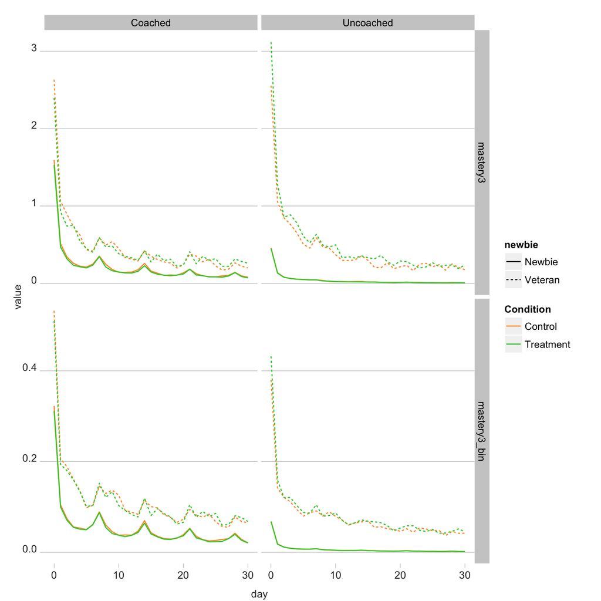

```r
gdf <- group_by(d[d$post==1,], condition, newbie, coached, day ) %.%
  summarise( mastery3=mean(mastery3) ,
             mastery3_bin=mean(mastery3_bin)
             )

# melt the data for graphing
library(reshape2)
m <- melt( gdf , id.vars=c("condition","coached","day","newbie") )

# absolute effects on various outcomes
ggplot( m, aes( day, value, linetype=newbie, color=condition ) ) +
  geom_path() +
  facet_grid( variable ~ coached, scales="free"  )  +
  color_conditions_scale + ht
```

#### Relative Mastery Progress

Mastery treatment progress scaled relative to the matched control group, i.e., control group progress = 100 for each given day.

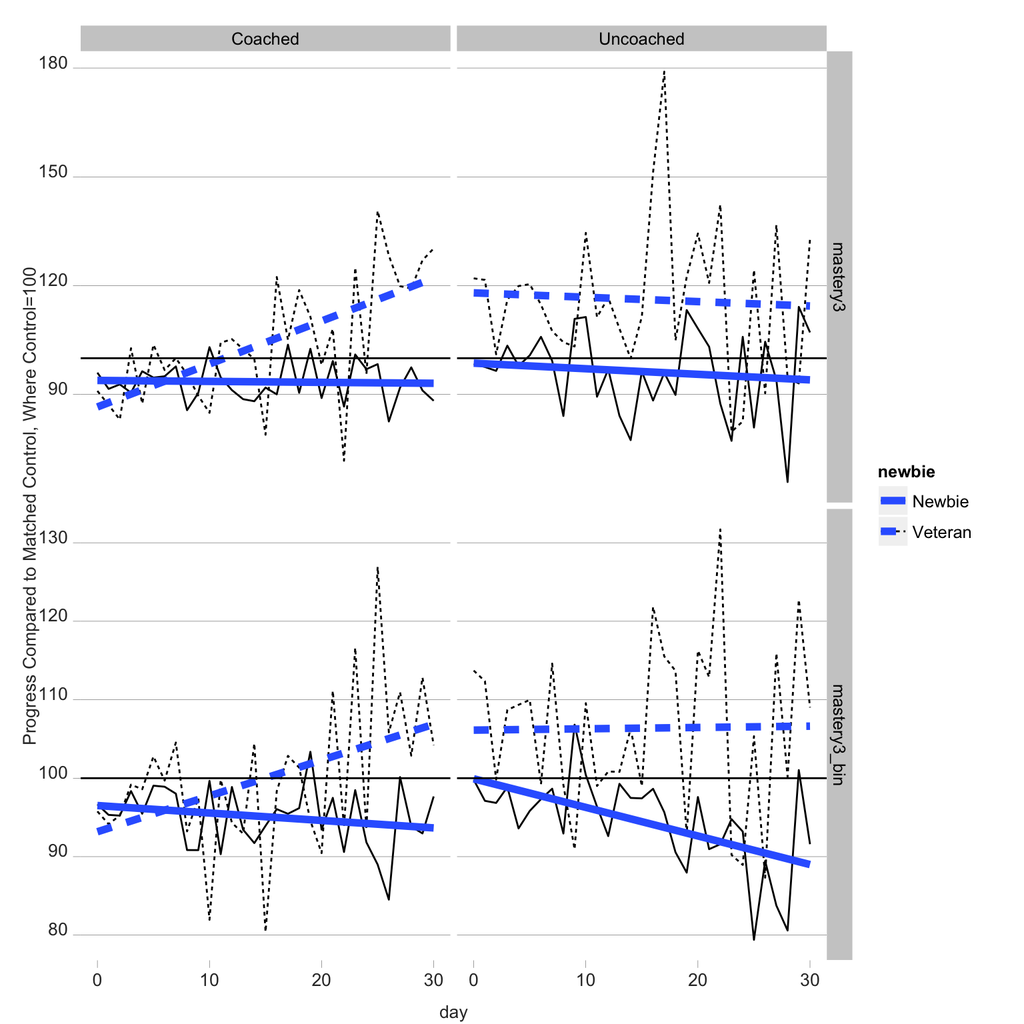

```r
# scale the effect by the control group, i.e., control group = 100
gdf <-merge( m[m$condition %in% "Treatment",] ,
             m[m$condition %in% "Control",] ,
             by=c("coached","newbie","day","variable"),
             suffixes=c("_treatment","_control")
             )
gdf$es <- gdf$value_treatment / gdf$value_control * 100
gdf$es[ is.na(gdf$es) ] <- 100

ggplot( gdf[order(gdf$day),], aes( day, es, linetype=newbie ) ) +
  geom_path() +
  geom_smooth( se=FALSE, method="lm", size=2 ) +
  geom_hline( yintercept=100 ) +
  ylab("Progress Compared to Matched Control, Where Control=100") +
  facet_grid( variable ~ coached, scales="free"  ) +
  ht
```

## Supplemental Analysis of Engagement

To investigate the cause of the difference in effect between coached and uncoached users, we examined active hours spent on site. We thought that maybe coached users tend to spend a fixed amount of time on site (because they’re in class) whereas uncoached users spend a flexible amount of time on site. If that were the case, it would be plausible that treatment had a negative effect on coached users by distracting them but a positive effect for uncoached users by motivating them to spend more time work.

In fact, there were no significant effects of condition on time-on-site.

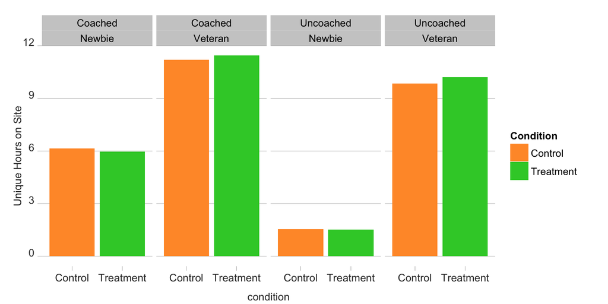

```r
ggplot( w,
  aes( condition, total_active_hours, fill=condition ) ) +
  geom_bar( stat="summary", fun.y="mean" ) +
  fill_conditions_scale +
  ylab("Unique Hours on Site") +
  facet_grid( . ~ coached + newbie , scales="free"  ) +
  ht
```

```r
aggregate( total_active_hours ~ condition +
           newbie + coached,
           data=w , mean ) %>%
  pretty_table()
```

|  | condition | newbie | coached | total_active_hours |
| --- | --- | --- | --- | --- |
| 1 | Control | Newbie | Coached | 6.14 |
| 2 | Treatment | Newbie | Coached | 5.96 |
| 3 | Control | Veteran | Coached | 11.21 |
| 4 | Treatment | Veteran | Coached | 11.44 |
| 5 | Control | Newbie | Uncoached | 1.55 |
| 6 | Treatment | Newbie | Uncoached | 1.51 |
| 7 | Control | Veteran | Uncoached | 9.85 |
| 8 | Treatment | Veteran | Uncoached | 10.22 |